# Practical Machine Learning Project

Alex Looi

21 August 2015

### 1. Introduction

Six young healthy participants were asked to perform one set of 10 repetitions of the Unilateral Dumbbell Biceps Curl in five different fashions:

1. exactly according to the specification (Class A),
2. throwing the elbows to the front (Class B),
3. lifting the dumbbell only halfway (Class C),
4. lowering the dumbbell only halfway (Class D)
5. and throwing the hips to the front (Class E).

Class A corresponds to the correct execution of the exercise, while the other 4 classes correspond to common mistakes.

Data of the above activities will be collected from accelerometers on the belt, forearm, arm, and dumbell for each of the 6 participants.

### 2. Requirement

The goal of your project is to predict the manner in which they did the exercise. This is the “classe” variable in the training set using any of the other variables.

You should create a report describing:

1. how you built your model,
2. how you used cross validation,
3. what you think the expected out of sample error is,and why you made the choices you did.
4. use your prediction model to predict 20 different test cases.

### 3. Model Selection, Building, and Cross Validation

#### Model Selection

Since we are predicting 5 different outcomes (classe A - E) with a set of predictors, the model chosen will perform **classification**. In this project, 2 classification models were evaluated:

1. Recursive Partitioning and Regression Trees (Method **“rpart”** in caret package)
2. Breiman and Cutler’s random forests for classification and regression (Method **“rf”** in caret package).

#### Model Building & Cross-validation Technique

Before building the model, the data set undergoes a “cleaning” process as follows:

1. Each variable is first checked to see if more than 95% of its content are invalid (eg NAs, blanks). If more than 95% are invalid, then that variable will be discarded, since it is likely that it will not affect the model much.
2. Unrelevant variables, such as time stamp. time, user name, row index, etc.. are then removed.
3. The cleaned data are then split into training data set and test data set for **model building** and **cross validation**

There are a few possible ways to build a model and perform cross validation. To train a model, the **Train** function in R is used. For Cross Validation, Random Subsampling using **createDataPartition** function in R is used to split the data.

2 ways of splitting data are studied:

1. The first method is to split the data set “pml-training.csv” into 2 subsets: 75% of it into training data set, and 25% of it into testing data set. For each model (rpart and random forest). The training data set will be used to train the model and the testing data set will be used to evaluate the accuracy of the models. The model with the better average accuracy will be chosen as the final model. (Note that if the accuracies of both models are quite close, there will be a need to repeat the whole process a few times to get and compare the average accuracies between the 2 models). After the model has been selected, this process (including the spliting of data) will be repeated over and over again if necessary (say 10 times) and the accuracy developed each time will be averaged to get the final model accuracy. The reason for taking averages of multiple accuracy is that the average accuracy will be a better estimation of the actual accuracy (Out-of-Sample accuracy/error) as compared to just one instance of the model accuracy.
2. The second method is similar to the first, but instead of splitting the data set “pml-training.csv” in 2 subsets, the data set is split into 3 subsets: 60% of it into training data set, 20% of it into validation data set, 20% of it into testing data set. The training and validation data set will undergoes the same process as per method 1 to determine which is a better model. However, after selecting the final model, there is no need to repeat the model development again to calculate the average accuracy. The reason is because the testing data set (which is not used yet) will be use to check for the actual accuracy of the model, and it will be very representative of the actual accuracy (Out-of-Sample accuracy/error)

The advantage of the first method is that the amount of data in the training data set is larger as compared to the second method. Larger data set allows a better model to be trained (developed). However, since the test data set is being reused over and over again during the model development, the estimated error will still be optimistic as compared to the actual Out-of-Sample error.

For the second method, the training data set is smaller as compared to the first method. Therefore the quality of the model developed will be slightly inferior. However, since the test data set is only used once to evaluate the accuracy of the final model, the error obtained will be a better reprentation of the actual Out-of-Sample error. **(Note that Out-of-Sample error = 1 - Out-of-Sample accuracy)**

**For this project, method 2 is used since in my opinion, the data set is quite large (about 20,000 rows). All the parameters used in training the models are the default values**.

**Note also that for data splitting and model training, each will have their own local set.seed() to ensure that each trained model can be reproduced.**

### 4. Initial Model Evaluation and Cross Validation

As mentioned earlier, method 2 of splitting the data set was used. The reduced data set with **19622 of observations** was split into 3 subsets, which consist of training data set (60% - **11776 of observations**), validation data set (20% - **3923 of observations**), and testing data set (20% - **3923 of observations**).

Using Recursive Partitioning and Regression Trees **(rpart)**, and using the validation data set to cross validate the model, the **accuracy is 0.534**. And using Breiman and Cutler’s random forests **(rf)**, the **accuracy is 0.9924**. Since the difference is accuracies between the 2 model is large, there is no need to repeat the process to get the average accuracies. **Breiman and Cutler’s random forests is chosen since its accuracy is higher.**

The following graphs shows the random forest model Accuray and Kappa vs the number of mtry.

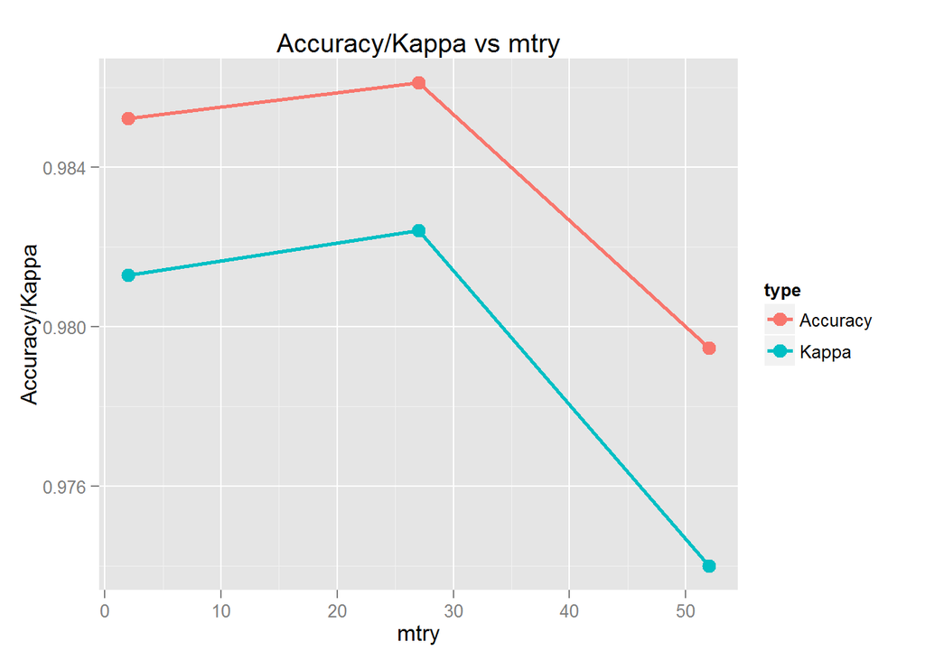

**Figure 1: Accuracy/Kappa vs Number of Predictor Used (mtry)**

From the graphs, we can see that the highest accuracy and kappa value occurs at the mtry value 27. (Note that these accuracies and kappas are the values calculated during the training of the model. It is NOT the accuracy and kappa when cross validated with the validation data set). **We can also see that the accuracy between the different values of mtry are more or less the same.**

The graph below shows the Variable Importance Plot of the model:

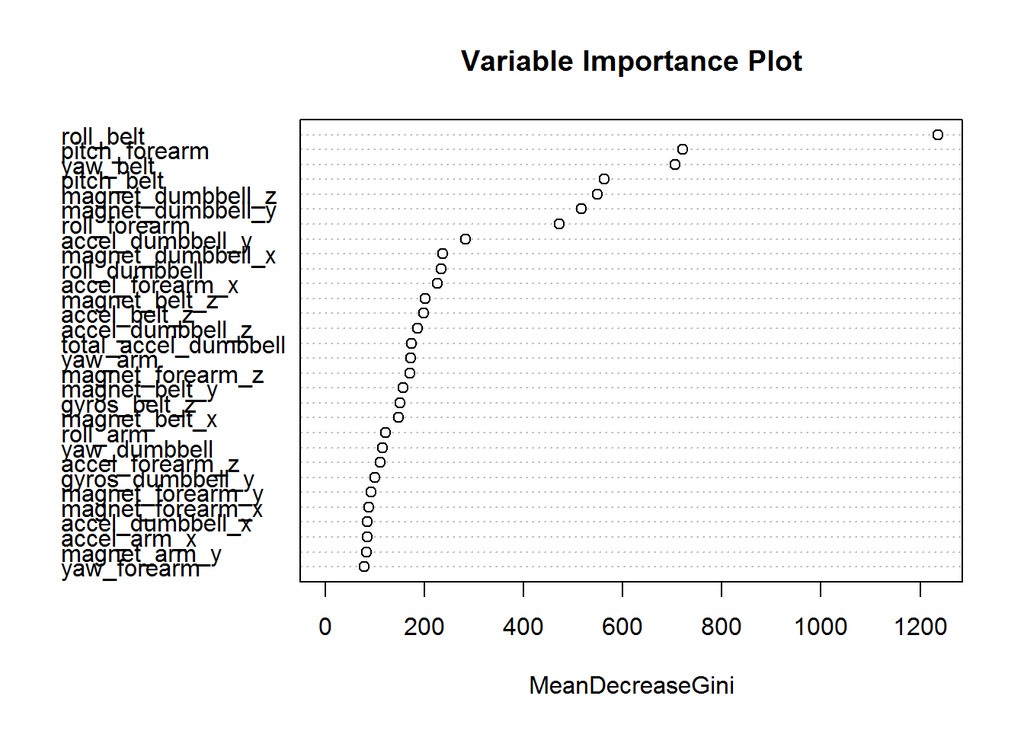

**Figure 2: Variable Importance Plot**

From the graph, it shows that the top 3 predictors that has the great Mean Decrease Gini value are **roll_belt**, **pitch_forearm** and **yaw_belt** . Higher Mean Decrease in Gini means that a particular predictor variable plays a greater role in partitioning the data into the defined classes. Also, it is likely that using the top 7 predictors may be sufficient to train a random forest model with a reasonable accuracy.

It is interesting to compare the time used to train the models. **rpart** uses **45.7 seconds (elapsed time)** while **rf** uses **1194.69 seconds (elapsed time)**. The time taken to train the model using random forest is very long. Therefore there is a need to fine tune the model to reduce the training time.

### 5. Model Fine Tuning

As the parameters used during model training are the default values, there may be a need to fine tune those parameters, either to increase accuracy of the model, or to reduce the training time. Improving one (eg accuracy) will be at the expense of the other (eg training time), so there is a need to manage the trade-offs.

For our model, the training time is very long. So the aim of fine tuning is to reduce the model training time, and at the same time, not sacrificing too much of the accuracy.

As we are using **Train** function in R, the only parameter that we can change is **mtry (number of predictors sampled for spliting at each node)** through the **tuneGrid** parameter in the **Train** function. Since there are a total of 52 predictor variables, **mtry** can range from 1 to 52.

As mentioned in the earlier section, since the accuracy between the different values of mtry are more or less the same, mtry of 2 was chosen to reduce the model training time (I didn’t choose mtry = 1 as I think it is too small). With mtry of 2, the accuracy of the final model when tested with the validation data set is **0.9944**. The training time is shortened to **284.33 seconds (elapsed time)**.

Since the accuracy is still good, this model (with mtry = 2) will be selected as the final model.

### 6. Testing with Testing Data Set.

With the final model selected, we will use the testing data set (that we have not used so far) to perform our final model accuracy estimation. This estimation will be close to the actual Out-of-Sample accuracy (or error), since the testing data set has not be used in anyway during the training of the model.

### 7. Final Assignment.

The final task for this project is to perform classification on the data set in the file “pml-testing.csv”. (The outcome will be used to fill in the 2nd part of this project and will not be shown here.)